# Partie II: Données de prêt de Prosper

**Présenté par Aby DIOUF**

Cet ensemble de données contient 113 937 prêts avec 81 variables sur chaque prêt, y compris le montant du prêt, le taux de l'emprunteur (ou taux d'intérêt), le statut actuel du prêt, le revenu de l'emprunteur, et bien d'autres.

Nous ne sommes pas censé explorer toutes les variables de l'ensemble de données ! Nous allons nous concentrer sur 14 variable d'entre elles.

## Effets des variables sur les prêts de Prosper

### Vue d'ensemble du jeu de données

Les données étaient constituées du montant initial des emprunts (**LoanOriginalAmount**), du rendement du prêteur sur le prêt(**LenderYield**), du taux d'intérêt de l'emprunteur sur un emprunt (**BorrowerRate**), Le taux annuel effectif global (TAEG) de l'emprunteur pour le prêt (**BorrowerAPR**) de la durée du prêt exprimé en mois (**Term**), du score de risque personnaliser pour chaque prêt (**ProsperScore**), du nombre d'investisseurs qui ont financés le prêt (**Investors**) et d'autres attributs. Les autres attributs comprenaient le status de l'emploi des emprunteurs (**EmploymentStatus**), le status du prêt (**LoanStatus**), la profession des emprunteurs (**Occupation**), le classement de prosper attribué à chaque prêt (**ProsperRating (Alpha))** etc. Les prêts sont aux totale $113937$ .

## importation des modules

## Chargement de l'ensembles des données

```
Les dix premiers lignes de l'ensembles des données
```

|  | ListingKey | ListingNumber | ListingCreationDate | CreditGrade | Term | LoanStatus | ClosedDate | BorrowerAPR | BorrowerRate | LenderYield | ... | LP_ServiceFees | LP_CollectionFees | LP_GrossPrincipalLoss | LP_NetPrincipalLoss | LP_NonPrincipalRecoverypayments | PercentFunded | Recommendations | InvestmentFromFriendsCount | InvestmentFromFriendsAmount | Investors |
| --- | --- | --- | --- | --- | --- | --- | --- | --- | --- | --- | --- | --- | --- | --- | --- | --- | --- | --- | --- | --- | --- |
| 0 | 1021339766868145413AB3B | 193129 | 2007-08-26 19:09:29.263000000 | C | 36 | Completed | 2009-08-14 00:00:00 | 0.16516 | 0.1580 | 0.1380 | ... | -133.18 | 0.0 | 0.0 | 0.0 | 0.0 | 1.0 | 0 | 0 | 0.0 | 258 |
| 1 | 10273602499503308B223C1 | 1209647 | 2014-02-27 08:28:07.900000000 | NaN | 36 | Current | NaN | 0.12016 | 0.0920 | 0.0820 | ... | 0.00 | 0.0 | 0.0 | 0.0 | 0.0 | 1.0 | 0 | 0 | 0.0 | 1 |
| 2 | 0EE9337825851032864889A | 81716 | 2007-01-05 15:00:47.090000000 | HR | 36 | Completed | 2009-12-17 00:00:00 | 0.28269 | 0.2750 | 0.2400 | ... | -24.20 | 0.0 | 0.0 | 0.0 | 0.0 | 1.0 | 0 | 0 | 0.0 | 41 |
| 3 | 0EF5356002482715299901A | 658116 | 2012-10-22 11:02:35.010000000 | NaN | 36 | Current | NaN | 0.12528 | 0.0974 | 0.0874 | ... | -108.01 | 0.0 | 0.0 | 0.0 | 0.0 | 1.0 | 0 | 0 | 0.0 | 158 |
| 4 | 0F023589499656230C5E3E2 | 909464 | 2013-09-14 18:38:39.097000000 | NaN | 36 | Current | NaN | 0.24614 | 0.2085 | 0.1985 | ... | -60.27 | 0.0 | 0.0 | 0.0 | 0.0 | 1.0 | 0 | 0 | 0.0 | 20 |
| 5 | 0F05359734824199381F61D | 1074836 | 2013-12-14 08:26:37.093000000 | NaN | 60 | Current | NaN | 0.15425 | 0.1314 | 0.1214 | ... | -25.33 | 0.0 | 0.0 | 0.0 | 0.0 | 1.0 | 0 | 0 | 0.0 | 1 |
| 6 | 0F0A3576754255009D63151 | 750899 | 2013-04-12 09:52:56.147000000 | NaN | 36 | Current | NaN | 0.31032 | 0.2712 | 0.2612 | ... | -22.95 | 0.0 | 0.0 | 0.0 | 0.0 | 1.0 | 0 | 0 | 0.0 | 1 |
| 7 | 0F1035772717087366F9EA7 | 768193 | 2013-05-05 06:49:27.493000000 | NaN | 36 | Current | NaN | 0.23939 | 0.2019 | 0.1919 | ... | -69.21 | 0.0 | 0.0 | 0.0 | 0.0 | 1.0 | 0 | 0 | 0.0 | 1 |
| 8 | 0F043596202561788EA13D5 | 1023355 | 2013-12-02 10:43:39.117000000 | NaN | 36 | Current | NaN | 0.07620 | 0.0629 | 0.0529 | ... | -16.77 | 0.0 | 0.0 | 0.0 | 0.0 | 1.0 | 0 | 0 | 0.0 | 1 |
| 9 | 0F043596202561788EA13D5 | 1023355 | 2013-12-02 10:43:39.117000000 | NaN | 36 | Current | NaN | 0.07620 | 0.0629 | 0.0529 | ... | -16.77 | 0.0 | 0.0 | 0.0 | 0.0 | 1.0 | 0 | 0 | 0.0 | 1 |

10 rows × 81 columns

## Séparation des variables numériques et des variables catégorielles

```
Variables categorielles
```

|  | LoanStatus | BorrowerState | EmploymentStatus | ProsperRating (Alpha) | Occupation |
| --- | --- | --- | --- | --- | --- |
| 0 | Completed | CO | Self-employed | NaN | Other |
| 1 | Current | CO | Employed | A | Professional |
| 2 | Completed | GA | Not available | NaN | Other |
| 3 | Current | GA | Employed | A | Skilled Labor |
| 4 | Current | MN | Employed | D | Executive |
| ... | ... | ... | ... | ... | ... |
| 113932 | Current | IL | Employed | C | Food Service Management |
| 113933 | FinalPaymentInProgress | PA | Employed | A | Professional |
| 113934 | Current | TX | Employed | D | Other |
| 113935 | Completed | GA | Full-time | C | Food Service |
| 113936 | Current | NY | Employed | A | Professor |

113937 rows × 5 columns

```
Variables numerique
```

|  | BorrowerAPR | BorrowerRate | LenderYield | LoanOriginalAmount |
| --- | --- | --- | --- | --- |
| 0 | 0.16516 | 0.1580 | 0.1380 | 9425 |
| 1 | 0.12016 | 0.0920 | 0.0820 | 10000 |
| 2 | 0.28269 | 0.2750 | 0.2400 | 3001 |
| 3 | 0.12528 | 0.0974 | 0.0874 | 10000 |
| 4 | 0.24614 | 0.2085 | 0.1985 | 15000 |
| ... | ... | ... | ... | ... |
| 113932 | 0.22354 | 0.1864 | 0.1764 | 10000 |
| 113933 | 0.13220 | 0.1110 | 0.1010 | 2000 |
| 113934 | 0.23984 | 0.2150 | 0.2050 | 10000 |
| 113935 | 0.28408 | 0.2605 | 0.2505 | 15000 |
| 113936 | 0.13189 | 0.1039 | 0.0939 | 2000 |

113937 rows × 4 columns

```
Statistique descriptives des variables numerique
```

|  | BorrowerAPR | BorrowerRate | LenderYield | LoanOriginalAmount |
| --- | --- | --- | --- | --- |
| count | 113912.000000 | 113937.000000 | 113937.000000 | 113937.00000 |
| mean | 0.218828 | 0.192764 | 0.182701 | 8337.01385 |
| std | 0.080364 | 0.074818 | 0.074516 | 6245.80058 |
| min | 0.006530 | 0.000000 | -0.010000 | 1000.00000 |
| 25% | 0.156290 | 0.134000 | 0.124200 | 4000.00000 |
| 50% | 0.209760 | 0.184000 | 0.173000 | 6500.00000 |
| 75% | 0.283810 | 0.250000 | 0.240000 | 12000.00000 |
| max | 0.512290 | 0.497500 | 0.492500 | 35000.00000 |

## Distribution du montant des prêts

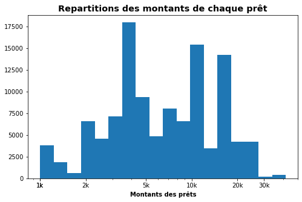

Le montant est une distribution à longue queue.Losque le montant est représenter avec une echelle logarithmique, on constate que la distributions du montant est un peu bimodale, avec un pic entre 3000 et 5000 et un second pic en 10000.

## Distributions du rendement du prêteur sur le prêt

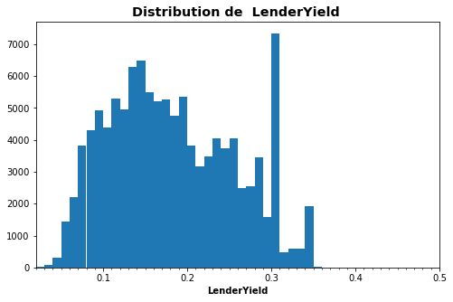

## Distrubution du taux d'intérêt de l'emprunteurs sur le prét

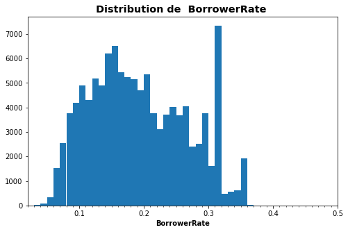

## Distribution du taux annuel effectif global (TAEG) de l'emprunteur pour le prêt.

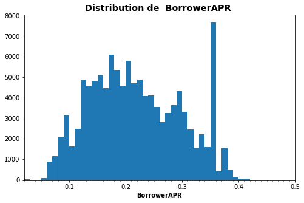

Ces trois derniers visualisation montre parfaitement que le rendement du prêteur sur le prêt (**LenderYield**), le taux d'intérêt de l'emprunteur sur le prêt (**BorrowerRate**) et le taux annuel effectif global (TAEG) de l'emprunteur pour le prêt (**BorrowerAPR**) sont proportionnelle. Donc nous allons explorer une seule de ces trois variables en fonction du montant des prêts.

## Distribution du rendement du prêteur sur le prêt en fonction du montant de chaque prêt.

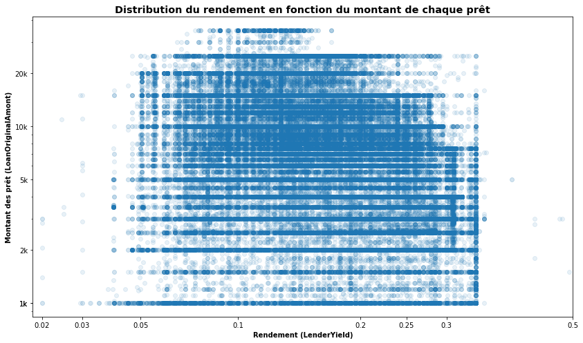